# 多元線性迴歸

wuyijin

2019年2月1日

# 多元線性迴歸

- 瞎猜進步到有根據的猜測
  - 將可能影響的原因列出來，將過去的經驗具體化，建立有根據的推論。
  - 憑經驗的猜測→→列出原因與觀察樣本→→有根據的推論。
- 找出影響因素到進一步解釋目標

  |  | 關聯性 | 解釋力 |
  | --- | --- | --- |
  | 目的 | 找出對於目標具有影響力的單個變數或多個變數， **建立目標和變數間的關聯性** | 讓變數和目標間的關聯性， 足以**解釋目標大部分的變異** |
  | 方法 | 衡量變數對於目標： 1.影響力的係數 2.統計上的顯著性 | 衡量模型： 1.解釋能力 2.基本的預測能力 |
  | 解決方案 | 找出可能具有影響力的解釋變數 建立目標(被解釋變數)和解釋變數間的關聯性 確定此關聯性，能充分解釋目標的變異 |  |

- 釐清目標和各個變數間的關係

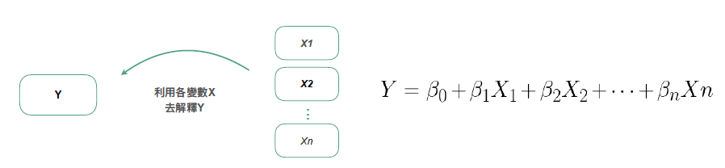

  - 1建立目標(Y，被解釋變數)和各變數(X，解釋變數)間的線性關係  
    2估計各個解釋變數的係數β，使此線性組合能去逼近真實的目標  
    3不論目標怎麼變化，都能用此組合掌握，並進一步解釋
- 用最簡單的數學來詮釋簡單的廻歸模型

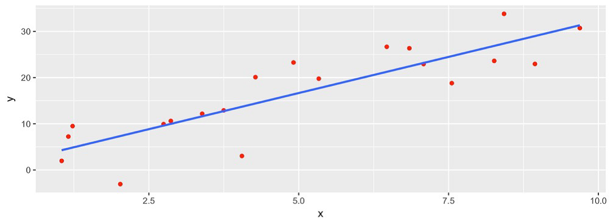

  - - **y = ax + b**
    - 圖中的藍線，可以表示成這個形式
    - 藍線能夠大致解釋紅色資料點的變化
    - 推廣到多維，就是多元迴歸分析

      |  | 解釋力 | 預測力 |
      | --- | --- | --- |
      | 效果 | 1.透過X的係數，了解它們如何影響Y 2.新增/去除某個變數後，各個變數的影響力會如何變化 | 1.解釋了Y大部分的變異後，此模型即抓到Y的趨勢 2.即使存在誤差，我們有信心說這是一個好的方法預測目標 |
      | 說明 | 例如β的係數是1000，表示X增加1時，Y會增加1000 | 無論各變數怎麼變化，都可以放入迴歸模型，得到預測的Y值 |

- 假說思考 - 用實驗精神解決模型中可能碰到的限制
  - 永遠無法得知真實的模型→→ 探討模型本身的數學意義 →→透過假說思考驗證
  - 透過假說思考主要驗證以下三點：
    - 1模型是否有足夠的解釋力
    - 2變數對於目標的解釋力與意義
    - 3模型本身是否有意義
  - 假說思考
    - 提出假說:針對商業命題，對不同的變數、模型提出初步的假設
    - 驗證假說:透過數學及統計上的意義，驗證假說是否成立
    - 回答問題:以驗證的結果，回答商業分析的命題
- 迴歸分析的計算核心 - 最小平方法

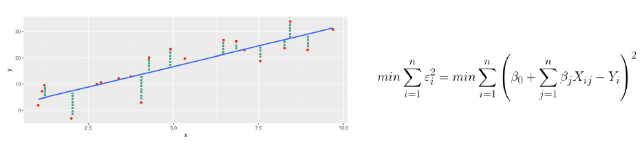

  - - 綠色虛線表示原始資料點(紅點)到預測資料點(藍線)的距離(殘差)
    - 利用最適化的方法估計出一組係數，使得**殘差平方和最小**
  - 最小平方法流程

    | Step 1: 選定一組係數，並計算誤差的平方總和 Step 2: 往誤差更小的方向修正(微分、梯度)，並更新係數 Step 3: 重複 Step 1 & Step 2，直到誤差的平方總和最小為止 |
    | --- |

  - 假設檢定回答商業問題

    |  | 提出假說 | 驗證假說 |  | 進行修正 |
    | --- | --- | --- | --- | --- |
    | R平方 | 在簡單回歸模型中，可以Y和X間的相關係數的平方， 推廣到多元迴歸中，即是多個X可以解釋多少Y的變異 目前的模型足以解釋Y大部分的變異 (模型針對目標的解釋能力) | 計算R平方值 | →→→→→ 解釋力過低 | 納入新的變數 進行變數轉換 嘗試不同變數組合 |
    | F檢定 | 針對整個模型進行檢定， 判斷此模型的解釋能力是否具備統計上的顯著性 目前的模型至少有一些解釋Y變異的能力 (針對整個模型進行檢定) | H0:模型不具解釋能力 H1:模型至少有解釋能力 | →→→→→ 無法拒絕 虛無假設 | 納入新的變數 進行變數轉換 嘗試不同變數組合 |
    | t檢定 | 針對單一變數進行檢定， 判斷此變數對於目標的解釋能力是否具備統計上的顯著性 使用的X變數對於Y至少有一些解釋能力 (針對單一變數進行檢定) | H0:該變數不具解釋能力 H1:該變數至少有解釋能力 | →→→→→ 無法拒絕 虛無假設 | 剔除該變數 進行變數轉換 |

# 凡有預測，必有誤差

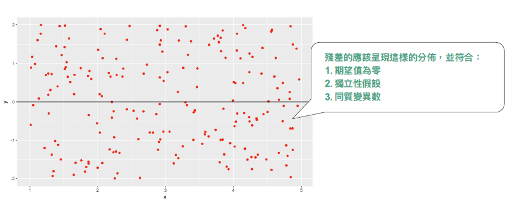

- - 殘差的三個假設
    - 殘差分布是很均勻的散落在零的上下
    - 在不同的X值或不同的Y值，殘差是沒有明顯趨勢
    - 剩餘隨機分布的誤差，模型無法再優化，即可輔助商業決策
- 總結迴歸模型與假說思考的流程

  | 提出假說 |  | 驗證假說 |  | 回答問題 |
  | --- | --- | --- | --- | --- |
  | 從樣本的觀察中， 對解釋變數X和目標Y 之間的關聯提出假說 | ←←← 未通過 | 1.利用最小平方法建立迴歸模型 2.檢定變數及模型的解釋能力和統計顯著性 | →→→ 通過 | 解釋力: 從係數說明各X對於目標Y的影響 預測力: 利用模型更準確地預測目標Y值 |